**Physics-informed Neural Networks (PINN)**

By Prof. Seungchul Lee  
http://iai.postech.ac.kr/  
Industrial AI Lab at POSTECH

**Table of Contents**

# 1. Why Deep Learning Needs Physics?

Why do data-driven ‘black-box’ methods fail?

- May output result that is physically inconsistent
- Easy to learn spurious relationships that look good only on training and test data
  - Can lead to poor generalization outside the available data (out-of-sample prediction tasks)
- Interpretability is absent
  - Discovering the mechanism of an underlying process is crucial for scientific advancements

Physics-Informed Neural Networks (PINNs)

- Take full advantage of data science methods with the accumulated prior knowledge of scientific theories $\rightarrow$ Improve predictive performance
- Integration of domain knowledge to overcome the issue of imbalanced data & data shortage

## 1.1. Taxonomy of Informed Deep Learning

[figure not shown]

## 1.2. Multilayer Feedforward Networks are Universal Approximators

- The Universal Approximation Theorem
  - Neural Networks are capable of approximating any Borel measurable function
  - Neural Networks (1989)

[figure not shown]

## 1.3. Neural Networks for Solving Differential Equations

- Neural Algorithm for Solving Differential Equations
  - Journal of Computational Physics (1990)
  - Neural minimization for finite difference equation

[figure not shown]

- ANN for ODE and PDE
  - IEEE on Neural Networks (1998)

[figure not shown]

## 1.4. Journal of Computational Physics (2019)

[figure not shown]

## 1.5. Nature Reviews Physics (2021)

[figure not shown]

# 2. Architecture of Physics-informed Neural Networks (PINN)

- NN as an universal function approximator
- Given
  - Some measured data from initial and boundary conditions
  - ODE or PDE

$$ \frac{\partial u}{\partial t} - \lambda \frac{\partial^2 u}{\partial x^2} = 0 $$

- Adding constraints for regularization
  - Regularized by physics, but matched with sparse data

$$ \begin{align*} \mathcal{L} &= \omega_{\text{data}} \mathcal{L}_{\text{data}} + \omega_{\text{PDE}} \mathcal{L}_{\text{PDE}}\\\\\\ \mathcal{L}_{\text{data}} &= \frac{1}{N_{\text{data}}} \sum \left(u(x,t) - u \right)^2 \\ \mathcal{L}_{\text{PDE}} &= \frac{1}{N_{\text{PDE}}} \sum \left(\frac{\partial u}{\partial t} - \lambda \frac{\partial^2 u}{\partial x^2} \right)^2 \end{align*} $$

[figure not shown]

# 3. Methond for Solving ODE with Neural Networks

## 3.1. Background

[This is a result first due to Lagaris et.al from 1998.](https://arxiv.org/pdf/physics/9705023.pdf) The idea is to solve differential equations using neural networks by representing the solution by a neural network and training the resulting network to satisfy the conditions required by the differential equation.

Consider a system of ordinary differential equations

$$ {u^\prime} = f(u,t) $$

with $t \in [0, 1]$ and a known initial condition $u(0) = u_0$.

To solve this, we approximate the solution by a neural network:

$$ {\text{NN}(t)} \approx {u(t)} $$

If $\text{NN}(t)$ was the true solution, then it would hold that $\text{NN}'(t) = f\left(\text{NN}(t),t \right)$ for all $t$. Thus we turn this condtion into our loss function. This motivates the loss function.

$${L(\omega)} = \sum_{i} \left(\frac{d \text{NN}(t_i)}{dt}-f\left(\text{NN}(t_i),t_i \right)\right)^2$$

The choice of $t_i$ could be done in many ways: it can be random, it can be a grid, etc. Anyways, when this loss function is minimized (gradients computed with standard reverse-mode automatic differentiation), then we have that $\frac{dNN(t_i)}{dt} \approx f(\text{NN}(t_i),t_i)$ and thus $\text{NN}(t)$ approximately solves the differential equation.

Note that we still have to handle the initial condition. One simple way to do this is to add an initial condition term to the cost function.

$${L(\omega)} = \sum_{i} \left(\frac{d \text{NN}(t_i)}{dt}-f(\text{NN}(t_i),t_i)\right)^2 + (\text{NN}(0)-u_0)^2 $$

where $\omega$ are the parameters that define the neural network $\text{NN}$ that approximates $u$. Thus this reduces down, once again, to simply finding weights which minimize a loss function !

## 3.2. Lab 1: Simple Example

- Let's look at the ODE:

$$\frac{du}{dt} = \cos2\pi t$$

- Initial condition:

$$u(0) = 1$$

- The exact solution:

$$u(t) = \frac{1}{2\pi}\sin2\pi t + 1$$

- Make a neural network and loss functions like below:

[figure not shown]

### 3.2.1. Import Library

```python
import numpy as np
import matplotlib.pyplot as plt
import tensorflow as tf
import random
```

### 3.2.2. Define Network and Hyper-parameters

```python
NN = tf.keras.models.Sequential([
    tf.keras.layers.Input((1,)),
    tf.keras.layers.Dense(units = 32, activation = 'tanh'),
    tf.keras.layers.Dense(units = 32, activation = 'tanh'),
    tf.keras.layers.Dense(units = 32, activation = 'tanh'),
    tf.keras.layers.Dense(units = 1)
])

NN.summary()
```

```
Model: "sequential"
_________________________________________________________________
 Layer (type)                Output Shape              Param #
=================================================================
 dense (Dense)               (None, 32)                64

 dense_1 (Dense)             (None, 32)                1056

 dense_2 (Dense)             (None, 32)                1056

 dense_3 (Dense)             (None, 1)                 33

=================================================================
Total params: 2,209
Trainable params: 2,209
Non-trainable params: 0
_________________________________________________________________
```

```python
optm = tf.keras.optimizers.Adam(learning_rate = 0.001)
```

### 3.2.3. Define ODE System

- ODE loss:

$$L_{\text{ODE}} = \frac{1}{n}\sum_{i=1}^{n} \left(\frac{d \text{NN}(t_i)}{dt}- \cos2\pi t_i\right)^2$$

- Initial condition loss:

$$L_{IC} = \frac{1}{n}\sum_{i=1}^{n} \left({\text{NN}(0)}- 1\right)^2$$

- Total loss:

$$L_{\text{Total}} = L_{\text{ODE}} + L_{\text{IC}}$$

```python
def ode_system(t, net):
    t = t.reshape(-1,1)
    t = tf.constant(t, dtype = tf.float32)
    t_0 = tf.zeros((1,1))
    one = tf.ones((1,1))

    with tf.GradientTape() as tape:
        tape.watch(t)

        u = net(t)
        u_t = tape.gradient(u, t)

    ode_loss = u_t - tf.math.cos(2*np.pi*t)
    IC_loss = net(t_0) - one

    square_loss = tf.square(ode_loss) + tf.square(IC_loss)
    total_loss = tf.reduce_mean(square_loss)

    return total_loss
```

### 3.2.4. Train & Prediction

```
1.7445493
0.0003114283
0.0002242499
0.00014402653
8.462762e-05
7.19602e-05
```

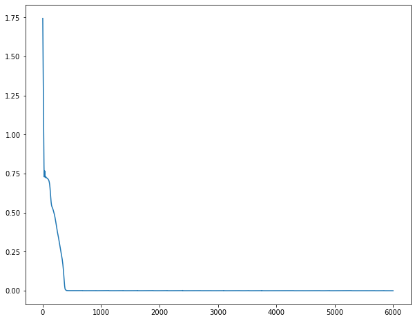

```python
train_t = (np.array([0., 0.025, 0.475, 0.5, 0.525, 0.9, 0.95, 1., 1.05, 1.1, 1.4, 1.45, 1.5, 1.55, 1.6, 1.95, 2.])).reshape(-1, 1)
train_loss_record = []

for itr in range(6000):
    with tf.GradientTape() as tape:
        train_loss = ode_system(train_t, NN)
        train_loss_record.append(train_loss)

        grad_w = tape.gradient(train_loss, NN.trainable_variables)
        optm.apply_gradients(zip(grad_w, NN.trainable_variables))

    if itr % 1000 == 0:
        print(train_loss.numpy())

plt.figure(figsize = (10,8))
plt.plot(train_loss_record)
plt.show()
```

[figure not shown]

```python
test_t = np.linspace(0, 2, 100)

train_u = np.sin(2*np.pi*train_t)/(2*np.pi) + 1
true_u = np.sin(2*np.pi*test_t)/(2*np.pi) + 1
pred_u = NN.predict(test_t).ravel()

plt.figure(figsize = (10,8))
plt.plot(train_t, train_u, 'ok', label = 'Train')
plt.plot(test_t, true_u, '-k',label = 'True')
plt.plot(test_t, pred_u, '--r', label = 'Prediction')
plt.legend(fontsize = 15)
plt.xlabel('t', fontsize = 15)
plt.ylabel('u', fontsize = 15)
plt.show()
```

# 4. Lab 2: Solve Lab 1 Again using DeepXDE

## 4.1. DeepXDE

- Using [DeepXDE](https://deepxde.readthedocs.io/en/latest/) libray
- DeepXDE is a useful library for solving forward and inverse partial differential equations (PDEs) via physics-informed neural network (PINN)

```python
!pip install deepxde
```

```
     |████████████████████████████████| 132 kB 5.1 MB/s
     |████████████████████████████████| 100 kB 10.4 MB/s
```

```python
# from deepxde.backend.set_default_backend import set_default_backend
# set_default_backend("tensorflow")
```

## 4.2. Problem Setup Again

- ODE

$$\frac{du}{dt} = \cos2\pi t$$

- Boundary condition:

$$u(0) = 1$$

- The exact solution:

$$u(t) = \frac{1}{2\pi}\sin2\pi t + 1$$

### 4.2.1. Import Library

```python
import tensorflow as tf
import deepxde as dde
import numpy as np
import matplotlib.pyplot as plt
import math as m
```

```
Deepxde backend not selected or invalid. Assuming tensorflow.compat.v1 for now.
Using backend: tensorflow.compat.v1
```

[output not shown]

### 4.2.2. Define ODE System

```python
pi = tf.constant(m.pi)

def ode_system(t, u):
    du_t = dde.grad.jacobian(u, t)
    return du_t - tf.math.cos(2*pi*t)
```

### 4.2.3. Define Initial Condition

```python
def boundary(t, on_initial):
    return on_initial and np.isclose(t[0], 0)
```

### 4.2.4. Define Geometry & Implement Initial Condition

```python
geom = dde.geometry.TimeDomain(0, 2)

ic = dde.IC(geom, lambda t: 1, boundary)

# Reference solution to compute the error
def true_solution(t):
    return np.sin(2*np.pi*t)/(2*np.pi) + 1

data = dde.data.PDE(geom,
                    ode_system,
                    ic,
                    num_domain = 30,
                    num_boundary = 2,
                    solution = true_solution,
                    num_test = 100)
```

### 4.2.5. Define Network and Hyper-parameters

```python
layer_size = [1] + [32] + [1]
activation = "tanh"
initializer = "Glorot uniform"

NN = dde.maps.FNN(layer_size, activation, initializer)
```

```python
model = dde.Model(data, NN)
model.compile("adam", lr = 0.001)
```

```
Compiling model...
Building feed-forward neural network...
'build' took 0.036146 s

'compile' took 0.199044 s
```

### 4.2.6. Train & Prediction

```
Initializing variables...
Training model...

Step      Train loss              Test loss               Test metric
0         [5.17e-01, 1.00e+00]    [5.11e-01, 1.00e+00]    []
1000      [3.87e-01, 4.56e-04]    [4.15e-01, 4.56e-04]    []
2000      [2.56e-01, 3.67e-05]    [2.56e-01, 3.67e-05]    []
3000      [5.72e-02, 1.75e-06]    [5.49e-02, 1.75e-06]    []
4000      [7.51e-03, 3.48e-08]    [6.90e-03, 3.48e-08]    []
5000      [3.88e-03, 6.03e-09]    [2.87e-03, 6.03e-09]    []
6000      [3.02e-03, 2.29e-08]    [2.10e-03, 2.29e-08]    []

Best model at step 6000:
  train loss: 3.02e-03
  test loss: 2.10e-03
  test metric: []

'train' took 5.522096 s
```

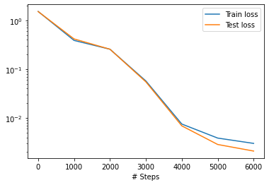

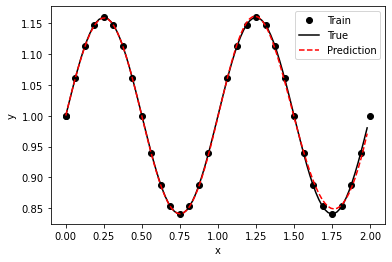

```python
losshistory, train_state = model.train(epochs = 6000)
dde.saveplot(losshistory, train_state, issave = False, isplot = True)
```

# 5. Lab 3: Spring and Mass System

## 5.1. Problem Setup

- We will solve a spring coupled masses problem:

[figure not shown]

- Problem properties

$$m_1 = 1 \operatorname{kg}, \quad m_2 = 1 \operatorname{kg}, \quad k_1 = 5 \operatorname{N/m}, \quad k_2 = 2 \operatorname{N/m}, \quad L_1 = 0.5 \operatorname{m}, \quad L_2 = 0.5 \operatorname{m}$$

- Initial properties

$$d_1 = 0.5 \operatorname{m}, \quad d_2 = 3.25 \operatorname{m}, \quad v_1 = 0 \operatorname{m/s}, \quad v_2 = 0 \operatorname{m/s}$$

- Partial differential equations

$$m_1 \ddot{x_1} + k_1 (x_1 - L_1) - k_2 (x_2 -x_1 - L_2) = 0$$
$$m_2 \ddot{x_2} + k_2 (x_2 -x_1 - L_2) = 0$$

- One Dirichlet initial condition:

$$x_1(0) = 0.5, \quad x_2(0) = 3.25$$

- One Neumann initial condition:

$$\dot{x_1}(0) = 0, \quad \dot{x_2}(0) = 0$$

- Make a neural network and loss functions like below :

[figure not shown]

## 5.2. Solve the Spring Coupled Masses Problem

### 5.2.1. Import Library

```python
import deepxde as dde
import numpy as np
import matplotlib.pyplot as plt
from scipy.integrate import odeint
```

```
Using backend: pytorch
Other available backends: tensorflow.compat.v1, tensorflow, jax, paddle.
paddle supports more examples now and is recommended.
```

### 5.2.2. Initial Constantsm

```python
# Masses
m1 = 1.0
m2 = 1.0
# Spring constants
k1 = 5.0
k2 = 2.0
# Natural lengths
L1 = 0.5
L2 = 0.5

# Initial conditions
# d1_0 and d2_0 are the initial displacements; v1_0 and v2_0 are the initial velocities
d1_0 = 0.5
d2_0 = 3.25

v1_0 = 0.0
v2_0 = 0.0

b1 = 0
b2 = 0

# maximum time to simulate
t_max = 5
```

### 5.2.3. Define PDE System

```python
def dy(t, x):
    return dde.grad.jacobian(x, t)
```

```python
def pde(t, x):
    # mass 1 location
    x_1 = x[:, [0]]
    # mass 2 location
    x_2 = x[:, [1]]


    dx1_tt = dde.grad.hessian(x, t, i = 0, j = 0, component = 0)
    dx2_tt = dde.grad.hessian(x, t, i = 0, j = 0, component = 1)

    pde1 = m1 * dx1_tt + k1 * (x_1 - L1) - k2 * (x_2 - x_1 - L1)
    pde2 = m2 * dx2_tt + k2 * (x_2 - x_1 - L1)

    return [pde1, pde2]
```

### 5.2.4. Define Initial Conditions

```python
def boundary_init(t, on_boundary):
    return on_boundary and np.isclose(t[0], 0)
```

```python
geom = dde.geometry.Interval(0, t_max)

init_d1 = dde.icbc.PointSetBC(np.array([0]), np.array([d1_0]).reshape(-1, 1), component=0)
init_d2 = dde.icbc.PointSetBC(np.array([0]), np.array([d2_0]).reshape(-1, 1), component=1)
init_v1 = dde.OperatorBC(geom, lambda x, y, _: dy(x, y[:, [0]]), boundary_init)
init_v2 = dde.OperatorBC(geom, lambda x, y, _: dy(x, y[:, [1]]), boundary_init)


data = dde.data.PDE(geom,
                    pde,
                    [init_d1, init_d2, init_v1, init_v2],
                    num_domain = 2000,
                    num_boundary = 100,
                    num_test = 1000)
```

### 5.2.5. Define Network and Hyper-parameters

```python
layer_size = [1] + [20] * 3 + [2]
activation = "tanh"
initializer = "Glorot uniform"

net = dde.maps.FNN(layer_size, activation, initializer)
```

```python
model = dde.Model(data, net)
model.compile("adam", lr = 1e-3)
```

```
Compiling model...
'compile' took 0.000123 s
```

### 5.2.6. Train & Prediction

```python
losshistory, train_state = model.train(epochs = 5000)
dde.saveplot(losshistory, train_state, issave = False, isplot = False)
```

[output not shown]

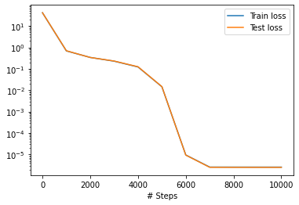

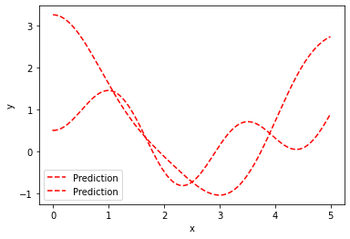

```python
dde.optimizers.config.set_LBFGS_options(maxiter=5000)
model.compile("L-BFGS")
losshistory, train_state = model.train()
dde.saveplot(losshistory, train_state, issave = False, isplot = True)
```

### 5.2.7. Evaluation

```python
def vectorfield(w, t, p):
    """
    Defines the differential equations for the coupled spring-mass system.

    Arguments:
        w :  vector of the state variables:
                  w = [x1,y1,x2,y2]
        t :  time
        p :  vector of the parameters:
                  p = [m1,m2,k1,k2,L1,L2,b1,b2]
    """
    x1, y1, x2, y2 = w
    m1, m2, k1, k2, L1, L2, b1, b2 = p

    # Create f = (x1',y1',x2',y2'):
    f = [y1,
         (-b1 * y1 - k1 * (x1 - L1) + k2 * (x2 - x1 - L2)) / m1,
         y2,
         (-b2 * y2 - k2 * (x2 - x1 - L2)) / m2]
    return f

# Use ODEINT to solve the differential equations defined by the vector field
# Parameter values



# ODE solver parameters
abserr = 1.0e-8
relerr = 1.0e-6
stoptime = t_max
numpoints = 250
t = geom.random_points(5000)

t[:,0].sort()
# Create the time samples for the output of the ODE solver.
# I use a large number of points, only because I want to make
# a plot of the solution that looks nice.

# Pack up the parameters and initial conditions:
p = [m1, m2, k1, k2, L1, L2, b1, b2]
w0 = [d1_0, v1_0, d2_0, v2_0]

# Call the ODE solver.
wsol = odeint(vectorfield, w0, t[:, 0], args=(p,),
              atol=abserr, rtol=relerr)
```

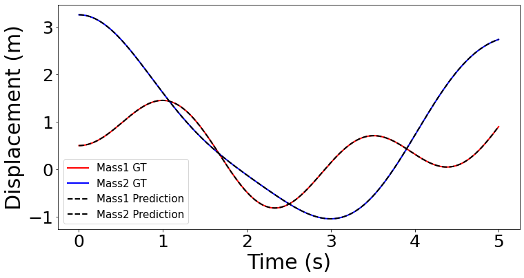

```python
result = model.predict(t)

usol1 = np.array(result[:, 0])
usol2 = np.array(result[:, 1])


lw = 2
plt.figure(figsize = (12, 6))
plt.plot(t,
            wsol[:, 0],
           alpha = 1,
            label = 'Mass1 GT',
        c = 'r',
        lw = lw
        )
plt.plot(t,
            wsol[:, 2],
           alpha = 1,
            label = 'Mass2 GT',
        c = 'b',
        lw = lw
        )
plt.plot(t[:, 0],
            usol1,
           alpha = 1,
            label = 'Mass1 Prediction',
         linestyle='dashed',
         c = 'k',
         lw = lw
           )
plt.plot(t[:, 0],
            usol2,
           alpha = 1,
            label = 'Mass2 Prediction',
         linestyle='dashed',
         c = 'k',
         lw = lw
           )
plt.legend(fontsize = 15)
plt.xticks(fontsize = 25)
plt.yticks(fontsize = 25)
plt.xlabel('Time (s)', fontsize = 30)
plt.ylabel('Displacement (m)', fontsize = 30)
plt.show()
```

```python
%%javascript
$.getScript('https://kmahelona.github.io/ipython_notebook_goodies/ipython_notebook_toc.js')
```